# TD4 ML - Credit scoring

Heriniaina Ramanantsoa & Thomas Duplanil

01/12/2020

# 1 Introduction

Les institutions financières peuvent subir des pertes importantes en raison du défaut de prêts automobiles. Cela a conduit à un resserrement de la souscription et à une augmentation des taux de rejet de crédits automobiles. La nécessité d’un meilleur modèle de notation du risque de crédit est par conséquent soulevé par la direction de l’institution “SuperCar4Everyone”. Cela justifie une étude pour identifier les drivers ou variables prédictrices du défaut de crédit automobile.

“SuperCar4Everyone” vous a donc embauché pour prédire avec précision la probabilité de défaut de l’emprunteur sur un prêt de véhicule dans le premier EMI (Equated Monthly Installment). L’EMI est un montant de paiement fixe effectué par un emprunteur à un prêteur à une date précise chaque mois civil. Des versements mensuels égaux sont utilisés pour rembourser les intérêts et le principal chaque mois, de sorte que sur un certain nombre d’années, le prêt soit remboursé intégralement.

Les informations suivantes concernant le prêt et le prêteur sont fournies:

- Informations sur le prêteur (données démographiques telles que l’âge, le revenu, la preuve d’identité, etc.)
- Informations sur le prêt (détails du décaissement, montant, IME, ratio prêt / valeur, etc.)
- Données et historique du bureau (score du bureau, nombre de comptes actifs, statut des autres prêts, historique de crédit, etc.)

Le modèle que vous allez construire doit garantir que les clients capables de rembourser ne seront pas rejetés. Pour cela, le modèle doit contenir les variables les plus discriminantes, sélectionnées par vos soins afin d’offrir la meilleure performance possible tel que l’entreprise “SuperCar4Everyone” pourra minimiser ses taux de défaut.

# 2 Les librairies utiles & les données

## 2.1 Les librairies

```r
# load useful libraries
library(tidyverse)
library(dplyr)
library(knitr)
library(skimr)
library(lubridate)
library(gridExtra)
library(scorecard)
library(ggplot2)
library(ggplotify)
library(plotly)
library(questionr)
library(caret)
library(pROC)
library(purrr)
```

## 2.2 Les Datas

Malgré leur système de données logé dans le cloud, l’entreprise «SuperCar4Everyone », vous met à disposition la forme la plus évoluée de stockage de données : le CSV. Ce fichier contient un certain nombre d’informations et un expert métier est là pour répondre à vos questions.

Contenu du fichier CSV:

- Primary accounts are those which the customer has taken for his personal use
- Secondary accounts are those which the customer act as a co-applicant or gaurantor

| Variable Name | Description |
| --- | --- |
| UniqueID | Identifier for customers |
| loan_default | Payment default in the first EMI on due date |
| disbursed_amount | Amount of Loan disbursed |
| asset_cost | Cost of the Asset |
| ltv | Loan to Value of the asset |
| branch_id | Branch where the loan was disbursed |
| supplier_id | Vehicle Dealer where the loan was disbursed |
| manufacturer_id | Vehicle manufacturer(Hero, Honda, TVS etc.) |
| Current_pincode | Current pincode of the customer |
| Date.of.Birth | Date of birth of the customer |
| Employment.Type | Employment Type of the customer (Salaried/Self Employed) |
| DisbursalDate | Date of disbursement |
| State_ID | State of disbursement |
| Employee_code_ID | Employee of the organization who logged the disbursement |
| MobileNo_Avl_Flag | if Mobile no. was shared by the customer then flagged as 1 |
| Aadhar_flag | if aadhar (Unique Identification Authority) was shared by the customer then flagged as 1 |
| PAN_flag | if pan (permanent account number) was shared by the customer then flagged as 1 |
| VoterID_flag | if voter was shared by the customer then flagged as 1 |
| Driving_flag | if DL was shared by the customer then flagged as 1 |
| Passport_flag | if passport was shared by the customer then flagged as 1 |
| PERFORM_CNS.SCORE | Bureau Score |
| PERFORM_CNS.SCORE.DESCRIPTION | Bureau score description |
| PRI.NO.OF.ACCTS | count of total loans taken by the customer at the time of disbursement |
| PRI.ACTIVE.ACCTS | count of active loans taken by the customer at the time of disbursement |
| PRI.OVERDUE.ACCTS | count of default accounts at the time of disbursement |
| PRI.CURRENT.BALANCE | total Principal outstanding amount of the active loans at the time of disbursement |
| PRI.SANCTIONED.AMOUNT | total amount that was sanctioned for all the loans at the time of disbursement |
| PRI.DISBURSED.AMOUNT | total amount that was disbursed for all the loans at the time of disbursement |
| SEC.NO.OF.ACCTS | count of total loans taken by the customer at the time of disbursement |
| SEC.ACTIVE.ACCTS | count of active loans taken by the customer at the time of disbursement |
| SEC.OVERDUE.ACCTS | count of default accounts at the time of disbursement |
| SEC.CURRENT.BALANCE | total Principal outstanding amount of the active loans at the time of disbursement |
| SEC.SANCTIONED.AMOUNT | total amount that was sanctioned for all the loans at the time of disbursement |
| SEC.DISBURSED.AMOUNT | total amount that was disbursed for all the loans at the time of disbursement |
| PRIMARY.INSTAL.AMT | EMI Amount of the primary loan |
| SEC.INSTAL.AMT | EMI Amount of the secondary loan |
| NEW.ACCTS.IN.LAST.SIX.MONTHS | New loans taken by the customer in last 6 months before the disbursment |
| DELINQUENT.ACCTS.IN.LAST.SIX.MONTHS | Loans defaulted in the last 6 months |
| AVERAGE.ACCT.AGE | Average loan tenure |
| CREDIT.HISTORY.LENGTH | Time since first loan |
| NO.OF_INQUIRIES | Enquries done by the customer for loans |

# 3 Le snorkeling

### 3.0.1 Chargement des fichiers et premières impressions

Data summary

| Name | datainput |
| --- | --- |
| Number of rows | 1639 |
| Number of columns | 34 |
| _______________________ |  |
| Column type frequency: |  |
| character | 6 |
| numeric | 28 |
| ________________________ |  |
| Group variables | None |

**Variable type: character**

| skim_variable | n_missing | complete_rate | min | max | empty | n_unique | whitespace |
| --- | --- | --- | --- | --- | --- | --- | --- |
| Date.of.Birth | 0 | 1.00 | 10 | 10 | 0 | 1216 | 0 |
| Employment.Type | 45 | 0.97 | 8 | 13 | 0 | 2 | 0 |
| DisbursalDate | 0 | 1.00 | 10 | 10 | 0 | 83 | 0 |
| PERFORM_CNS.SCORE.DESCRIPTION | 0 | 1.00 | 10 | 55 | 0 | 19 | 0 |
| AVERAGE.ACCT.AGE | 0 | 1.00 | 9 | 11 | 0 | 90 | 0 |
| CREDIT.HISTORY.LENGTH | 0 | 1.00 | 9 | 11 | 0 | 135 | 0 |

**Variable type: numeric**

| skim_variable | n_missing | complete_rate | mean | sd | p0 | p25 | p50 | p75 | p100 | hist |
| --- | --- | --- | --- | --- | --- | --- | --- | --- | --- | --- |
| UniqueID | 1 | 1 | 555242.73 | 66813.73 | 417614.00 | 502385.75 | 569790.50 | 610007.75 | 653991.00 | ▅▃▅▇▇ |
| disbursed_amount | 1 | 1 | 55200.00 | 13348.75 | 15579.00 | 47849.00 | 54506.50 | 60947.00 | 153318.00 | ▂▇▁▁▁ |
| asset_cost | 1 | 1 | 76311.90 | 19121.89 | 39684.00 | 66279.25 | 70879.50 | 78727.50 | 215528.00 | ▇▃▁▁▁ |
| ltv | 0 | 1 | 75.31 | 11.55 | 25.72 | 69.59 | 77.35 | 84.36 | 94.95 | ▁▁▂▇▆ |
| branch_id | 0 | 1 | 71.48 | 68.80 | 1.00 | 13.00 | 62.00 | 120.50 | 260.00 | ▇▅▃▁▁ |
| supplier_id | 1 | 1 | 19518.35 | 3536.43 | 12374.00 | 16280.75 | 18732.00 | 23000.00 | 24793.00 | ▃▅▃▃▇ |
| manufacturer_id | 0 | 1 | 69.60 | 21.72 | 45.00 | 48.00 | 86.00 | 86.00 | 145.00 | ▇▁▇▁▁ |
| Current_pincode_ID | 1 | 1 | 3264.90 | 2192.94 | 5.00 | 1506.50 | 2790.50 | 5298.75 | 7341.00 | ▇▇▅▅▆ |
| State_ID | 0 | 1 | 6.96 | 4.41 | 1.00 | 4.00 | 6.00 | 9.00 | 21.00 | ▇▅▂▁▁ |
| Employee_code_ID | 1 | 1 | 1546.41 | 987.18 | 3.00 | 728.00 | 1407.50 | 2337.75 | 3774.00 | ▇▇▆▅▃ |
| MobileNo_Avl_Flag | 0 | 1 | 1.00 | 0.00 | 1.00 | 1.00 | 1.00 | 1.00 | 1.00 | ▁▁▇▁▁ |
| Aadhar_flag | 0 | 1 | 0.83 | 0.37 | 0.00 | 1.00 | 1.00 | 1.00 | 1.00 | ▂▁▁▁▇ |
| PAN_flag | 0 | 1 | 0.08 | 0.26 | 0.00 | 0.00 | 0.00 | 0.00 | 1.00 | ▇▁▁▁▁ |
| VoterID_flag | 0 | 1 | 0.15 | 0.35 | 0.00 | 0.00 | 0.00 | 0.00 | 1.00 | ▇▁▁▁▂ |
| Driving_flag | 0 | 1 | 0.03 | 0.17 | 0.00 | 0.00 | 0.00 | 0.00 | 1.00 | ▇▁▁▁▁ |
| Passport_flag | 0 | 1 | 0.00 | 0.05 | 0.00 | 0.00 | 0.00 | 0.00 | 1.00 | ▇▁▁▁▁ |
| PERFORM_CNS.SCORE | 0 | 1 | 415.69 | 335.19 | 0.00 | 0.00 | 566.00 | 731.00 | 853.00 | ▇▁▁▅▇ |
| PRI.NO.OF.ACCTS | 0 | 1 | 3.56 | 5.73 | 0.00 | 0.00 | 2.00 | 4.00 | 104.00 | ▇▁▁▁▁ |
| PRI.ACTIVE.ACCTS | 0 | 1 | 1.56 | 2.30 | 0.00 | 0.00 | 1.00 | 2.00 | 24.00 | ▇▁▁▁▁ |
| PRI.OVERDUE.ACCTS | 0 | 1 | 0.22 | 0.60 | 0.00 | 0.00 | 0.00 | 0.00 | 8.00 | ▇▁▁▁▁ |
| PRI.CURRENT.BALANCE | 1 | 1 | 211663.46 | 709805.25 | -4826.00 | 0.00 | 8455.00 | 89068.50 | 10091566.00 | ▇▁▁▁▁ |
| PRI.SANCTIONED.AMOUNT | 1 | 1 | 265755.36 | 785740.77 | 0.00 | 0.00 | 24698.50 | 149000.00 | 10000000.00 | ▇▁▁▁▁ |
| PRI.DISBURSED.AMOUNT | 1 | 1 | 267509.04 | 804000.68 | 0.00 | 0.00 | 24443.00 | 150000.00 | 10000000.00 | ▇▁▁▁▁ |
| PRIMARY.INSTAL.AMT | 0 | 1 | 13058.75 | 130068.14 | 0.00 | 0.00 | 0.00 | 4618.50 | 4189968.00 | ▇▁▁▁▁ |
| NEW.ACCTS.IN.LAST.SIX.MONTHS | 0 | 1 | 0.58 | 1.15 | 0.00 | 0.00 | 0.00 | 1.00 | 13.00 | ▇▁▁▁▁ |
| DELINQUENT.ACCTS.IN.LAST.SIX.MONTHS | 0 | 1 | 0.14 | 0.45 | 0.00 | 0.00 | 0.00 | 0.00 | 7.00 | ▇▁▁▁▁ |
| NO.OF_INQUIRIES | 0 | 1 | 0.27 | 0.84 | 0.00 | 0.00 | 0.00 | 0.00 | 13.00 | ▇▁▁▁▁ |
| loan_default | 0 | 1 | 0.26 | 0.44 | 0.00 | 0.00 | 0.00 | 1.00 | 1.00 | ▇▁▁▁▃ |

La fonction skim nous permet d’avoir une vision plus précise du dataset : le nombre total de contrats (1639), les variables typées en ‘character’ ou ‘numeric’, les valeurs manquantes par variables (‘n_missing’) et leur poids.

Le format de certaines variables nécessite d’être retravaillé, une rapide vue des variables permet de se faire une première idée :

| ltv | disbursed_amount | Date.of.Birth | supplier_id | Employment.Type | PERFORM_CNS.SCORE.DESCRIPTION | loan_default | AVERAGE.ACCT.AGE | CREDIT.HISTORY.LENGTH |
| --- | --- | --- | --- | --- | --- | --- | --- | --- |
| 94.95 | 62447 | 01/12/1979 | 16694 | Salaried | M-Very High Risk | 1 | 4yrs 2mon | 9yrs 3mon |
| 94.61 | 58973 | 04/06/1966 | 23643 | Salaried | A-Very Low Risk | 0 | 3yrs 4mon | 8yrs 9mon |
| 94.19 | 71700 | 18/05/1981 | 15884 | Salaried | F-Low Risk | 1 | 1yrs 0mon | 1yrs 5mon |
| 94.10 | 83686 | 24/02/1987 | 24487 | Salaried | C-Very Low Risk | 0 | 1yrs 0mon | 2yrs 1mon |
| 93.88 | 67169 | 01/01/1983 | 15359 | Salaried | M-Very High Risk | 0 | 1yrs 3mon | 2yrs 11mon |
| 93.59 | 68663 | 26/02/1991 | 18348 | Salaried | D-Very Low Risk | 1 | 1yrs 8mon | 3yrs 2mon |

### 3.0.2 Echange avec les métiers

Une première sélection des variables peut se faire via un échange avec les banquiers, après tout, ils connaissent mieux leur métier que nous! Ils nous orientent sur les données qu’ils suivent pour mesurer le niveau de risque d’un client. Il sera utile de retenir à minima ces données et de les enrichir de variables que nous identifierons statistiquement.

Les étudiants doivent maintenant lire les descriptions des variables présentes, regarder les distributions et les premières valeurs et poser des questions aux métiers pour une présélection des variables et une étape de wrangling.

# 4 Deep dive

## 4.1 Wrangling et mise en forme

Garbage in, garbage out : la préparation de la donnée est une étape prépondérante. Une mauvaise ou insuffisante préparation de ses données peut tout simplement annuler toute la pertinence de votre modèle, aussi sophistiqué soit-il. Classiquement, la préparation des données couvre 80% du temps passé pour une modélisation.

Des modalités trop fragmentées sont difficilement interprétables par les métiers et n’apportent pas vraiment de plus-value. Un regroupement plus macro est souvent nécessaire.

Pour pouvoir interpréter le regroupement on peut passer du tableau en effectifs au tableau en pourcentages ligne ou colonne. Pour cela, on peut utiliser les fonctions lprop du package questionr.

Pour calculer les pourcentages ligne :

```
##
##                                         A-Very Low Risk
##                                                     150
##                                         B-Very Low Risk
##                                                      92
##                                         C-Very Low Risk
##                                                     161
##                                         D-Very Low Risk
##                                                     106
##                                              E-Low Risk
##                                                      55
##                                              F-Low Risk
##                                                      89
##                                              G-Low Risk
##                                                      40
##                                           H-Medium Risk
##                                                      74
##                                           I-Medium Risk
##                                                     133
##                                             J-High Risk
##                                                      46
##                                             K-High Risk
##                                                      82
##                                        L-Very High Risk
##                                                      13
##                                        M-Very High Risk
##                                                      84
##                             No Bureau History Available
##                                                     376
## Not Scored: No Activity seen on the customer (Inactive)
##                                                      40
##      Not Scored: No Updates available in last 36 months
##                                                      11
##   Not Scored: Not Enough Info available on the customer
##                                                      43
##                            Not Scored: Only a Guarantor
##                                                      14
##            Not Scored: Sufficient History Not Available
##                                                      30
```

```
##
##       High        Low     Medium Not Scored
##        225        693        207        514
```

```
##
##                                                           0     1     Total
##   A-Very Low Risk                                          90.7   9.3 100.0
##   B-Very Low Risk                                          88.0  12.0 100.0
##   C-Very Low Risk                                          82.6  17.4 100.0
##   D-Very Low Risk                                          80.2  19.8 100.0
##   E-Low Risk                                               89.1  10.9 100.0
##   F-Low Risk                                               79.8  20.2 100.0
##   G-Low Risk                                               87.5  12.5 100.0
##   H-Medium Risk                                            59.5  40.5 100.0
##   I-Medium Risk                                            72.2  27.8 100.0
##   J-High Risk                                              45.7  54.3 100.0
##   K-High Risk                                              47.6  52.4 100.0
##   L-Very High Risk                                         30.8  69.2 100.0
##   M-Very High Risk                                         41.7  58.3 100.0
##   No Bureau History Available                              76.6  23.4 100.0
##   Not Scored: No Activity seen on the customer (Inactive)  80.0  20.0 100.0
##   Not Scored: No Updates available in last 36 months       81.8  18.2 100.0
##   Not Scored: Not Enough Info available on the customer    81.4  18.6 100.0
##   Not Scored: Only a Guarantor                             50.0  50.0 100.0
##   Not Scored: Sufficient History Not Available             63.3  36.7 100.0
##   All                                                      74.4  25.6 100.0
```

```
##
##              0     1     Total
##   High        44.0  56.0 100.0
##   Low         85.1  14.9 100.0
##   Medium      67.6  32.4 100.0
##   Not Scored  75.9  24.1 100.0
##   All         74.4  25.6 100.0
```

Pour les problèmes plus complexes, un parsing plus fin est parfois nécessaire pour des données 4yrs 2mon, 3yrs 4mon, 1yrs 0mon, 1yrs 0mon, 1yrs 3mon, 1yrs 8mon , l’utilisation d’une expression régulière peut-être une solution. Ici nous voulons un time span et non une modalité (2yrs 3monts => 27 months).

| AVERAGE.ACCT.AGE | AAA | CREDIT.HISTORY.LENGTH | CHL |
| --- | --- | --- | --- |
| 4yrs 2mon | 50 | 9yrs 3mon | 111 |
| 3yrs 4mon | 40 | 8yrs 9mon | 105 |
| 1yrs 0mon | 12 | 1yrs 5mon | 17 |
| 1yrs 0mon | 12 | 2yrs 1mon | 25 |
| 1yrs 3mon | 15 | 2yrs 11mon | 35 |
| 1yrs 8mon | 20 | 3yrs 2mon | 38 |

La même question se pose sur les dates, une maturité ou un time span est toujours plus facilement interprétable qu’une date fixe. Elle donne une dimension de temporalité appréciée par les modélisateur et le métier.

| Date.of.Birth | BorrowerAge | DisbursalDate | NbrMonthRelation |
| --- | --- | --- | --- |
| 01/12/1979 | 41 | 31/10/2018 | 25.33333 |
| 04/06/1966 | 54 | 23/10/2018 | 25.60000 |
| 18/05/1981 | 39 | 19/09/2018 | 26.73333 |
| 24/02/1987 | 33 | 17/09/2018 | 26.80000 |
| 01/01/1983 | 37 | 28/09/2018 | 26.43333 |
| 26/02/1991 | 29 | 20/09/2018 | 26.70000 |

Nous pouvons ainsi regarder les données travaillées

- pour les variables numériques:

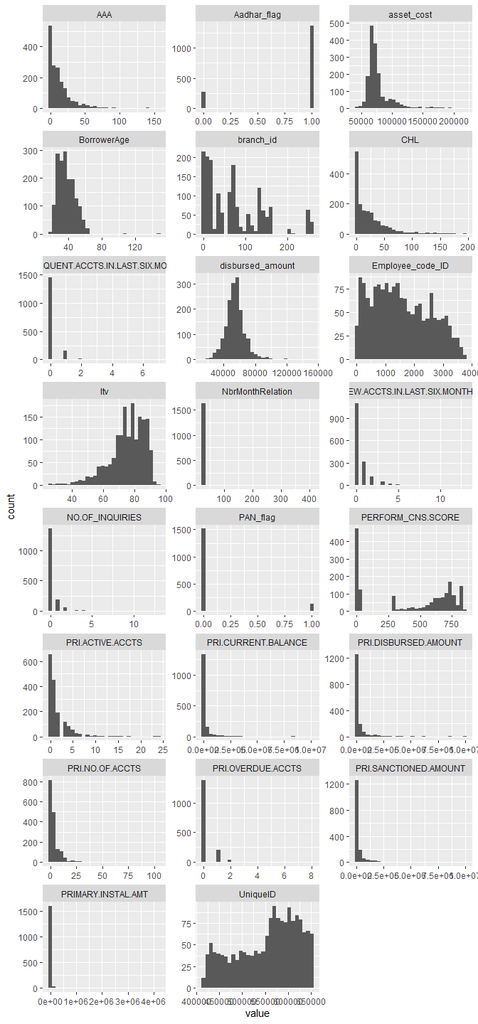

- pour les variables catégorielles:

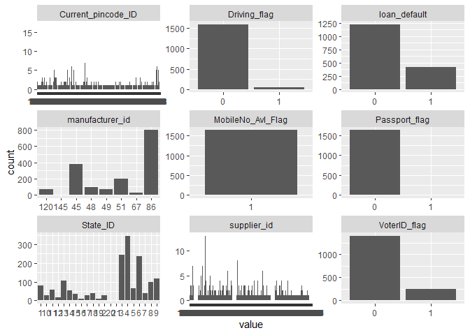

## 4.2 Discussion avec le business

Les modélisateurs doivent revenir avec des questions pour le business et exclure les premières variables

## 4.3 Sélection des variables pour le modèle

### 4.3.1 Analyses univariées & bivariées

Nous allons étudier une variable souvent révélatrice de la qualité de la saisie de la donnée. L’âge d’un client nous permet de détecter des valeurs fausses ou aberrantes. Les modélisateurs pourront étudier plusieurs variables qui semblent pertinentes pour faire le processus de sélection.

```
##    Min. 1st Qu.  Median    Mean 3rd Qu.    Max.
##   20.00   30.00   36.00   37.65   45.00  150.00
```

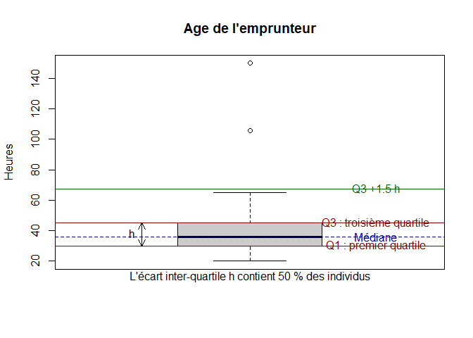

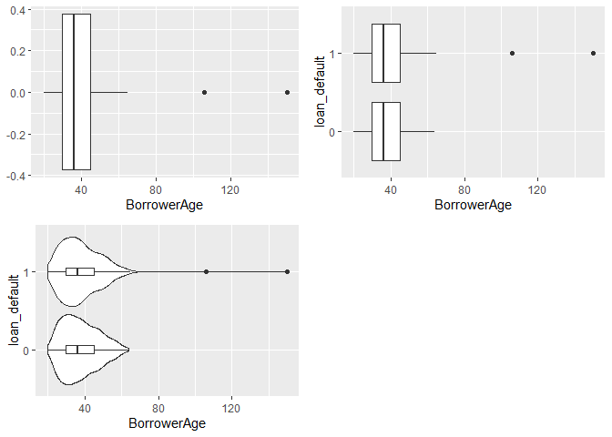

### 4.3.2 Discrétisation des variables

La discrétisation des variables est une pratique courante pour le credit scoring. Elle permet de transformer des variables numériques (âge, ancienneté du client, LTV) en variables catégorielle.

Il est à noter que la discrétisation d’une variable numérique constitue une perte d’information et n’est pas un pré-requis à la régression logistique. Néanmoins, la création de modalités permet souvent une lecture plus simple et une catégorisation des clients.

En discrétisant, nous cherchons le meilleur découpage de la variable à discrétiser vis à vis de notre variable cible. Plusieurs méthodes existent (khi2, WOE, arbres, etc.) mais le principe est toujours le même : commencer par un découpage fin et regrouper les modalités ayant le même taux de défaut.

Nous allons utiliser la fonction woebin du package scorecard. Il découpe sur la base de la mesure WOE ou Weigth of Evidence. Le package fournit également une fonction woebin_plot qui propose des graphiques lisibles des découpages (se limiter à 3 classes).

```
## [INFO] creating woe binning ...
## [INFO] Binning on 1639 rows and 30 columns in 00:00:24
```

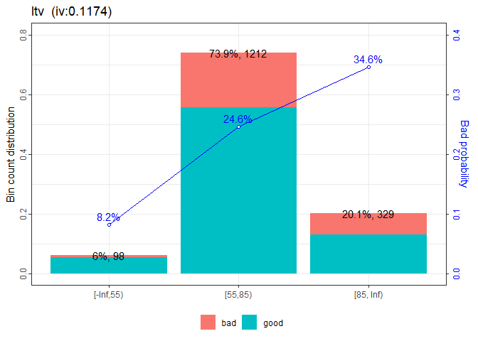

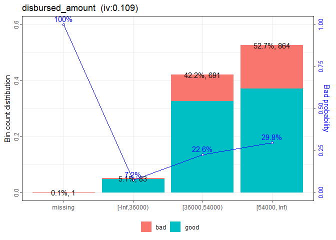

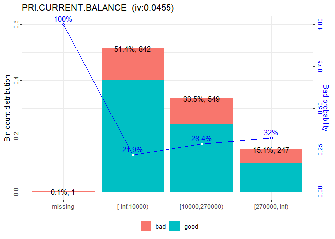

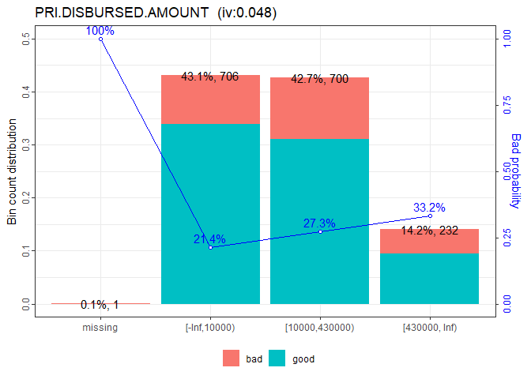

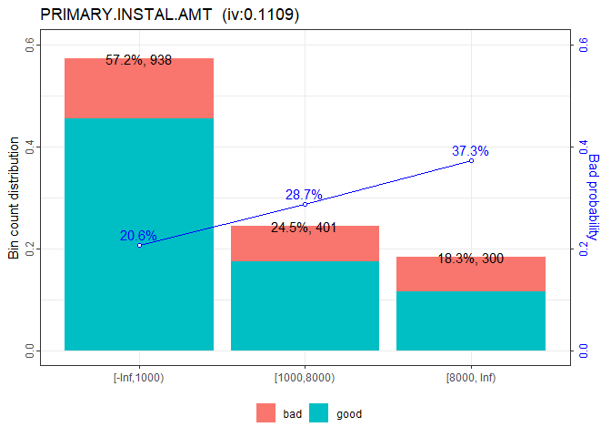

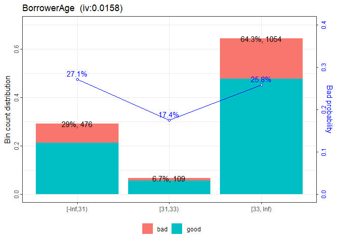

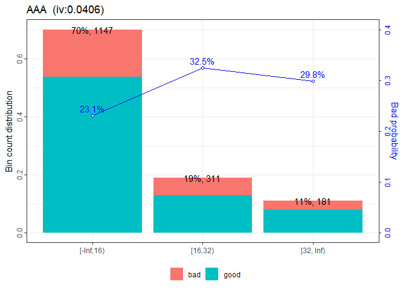

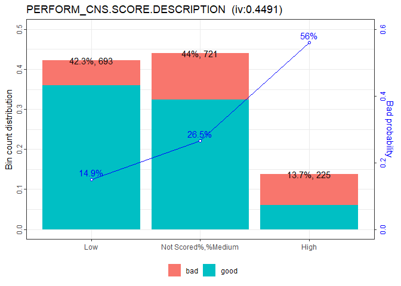

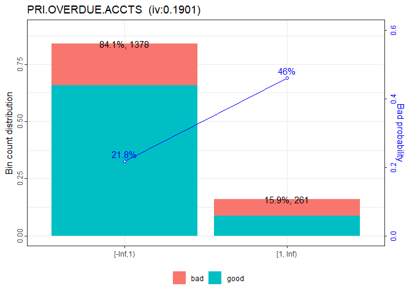

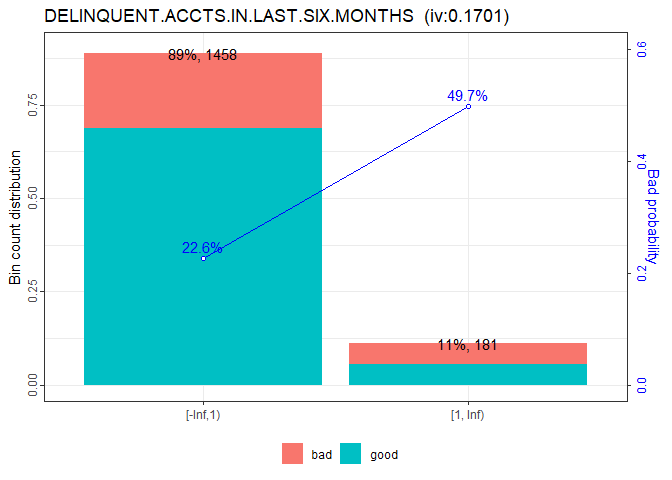

```
## [INFO] converting into woe values ...
```

### 4.3.3 Pouvoir discriminant des variables

Nous pouvons calculer l’information value (IV) pour chaque variable. Cette mesure classique dans le credit scoring permet de mesurer le pouvoir discriminant de chaque variable vis à vis du défaut. Plus l’IV est grand, plus le lien est fort.

| IV | Puissance de la relation |
| --- | --- |
| < 0.02 | très faible |
| 0.02 - 0.1 | faible |
| 0.1 - 0.3 | moyenne |
| 0.3 - 0.5 | forte |
| > 0.5 | très forte |

| variable | info_value |
| --- | --- |
| PERFORM_CNS.SCORE.DESCRIPTION_bin | 0.45 |
| PERFORM_CNS.SCORE_bin | 0.45 |
| PRI.OVERDUE.ACCTS_bin | 0.19 |
| DELINQUENT.ACCTS.IN.LAST.SIX.MONTHS_bin | 0.17 |
| ltv_bin | 0.12 |
| PRIMARY.INSTAL.AMT_bin | 0.11 |
| disbursed_amount_bin | 0.11 |
| PRI.ACTIVE.ACCTS_bin | 0.05 |
| CHL_bin | 0.05 |
| PRI.DISBURSED.AMOUNT_bin | 0.05 |
| PRI.CURRENT.BALANCE_bin | 0.04 |
| PRI.SANCTIONED.AMOUNT_bin | 0.04 |
| NO.OF_INQUIRIES_bin | 0.04 |
| AAA_bin | 0.04 |
| NbrMonthRelation_bin | 0.04 |
| supplier_id_bin | 0.04 |
| State_ID_bin | 0.04 |
| PRI.NO.OF.ACCTS_bin | 0.03 |
| BorrowerAge_bin | 0.02 |
| Employment.Type_bin | 0.01 |
| branch_id_bin | 0.01 |
| asset_cost_bin | 0.01 |
| manufacturer_id_bin | 0.01 |
| Aadhar_flag_bin | 0.01 |
| VoterID_flag_bin | 0.01 |
| PAN_flag_bin | 0.00 |
| NEW.ACCTS.IN.LAST.SIX.MONTHS_bin | 0.00 |

### 4.3.4 Corrélations intra modèle (Étape optionnelle)

L’utilisation de variables explicatives corrélées entre elles crée de nombreux biais. Instinctivement, on peut se dire qu’une redondance d’information n’est pas utile dans un modèle (si l’âge du client est discriminant, il n’est pas nécessaire de l’utiliser deux fois, en année et en mois par exemple).

De plus, dans une régression, la corrélation des drivers est un problème qui survient lorsque certaines variables de prévision du modèle mesurent le même phénomène. Une corrélation entre les drivers prononcée s’avère problématique, car elle peut perturber la valeur des coefficients de régression et les rendre instables et difficiles à interpréter. Ce phénomène de surapprentissage n’est pas souhaitable.

Pour ne retenir que les variables pertinentes, une analyse de corrélation est donc nécessaire. L’idée générale est de retenir les variables les plus discriminantes et les moins corrélées entre elles.

Le V de Cramer peut être utilisé en ce sens. Dérivée du khi2, cette mesure normalisée permet de quantifier une “corrélation” entre variables catégorielles :

| Valeurs du V de Cramer (en pct) | Puissance de la relation |
| --- | --- |
| <10 | très faible |
| >10 && <20 | faible |
| >20 && <30 | moyenne |
| >30 | forte |

Le calcul d’une matrice entre les variables d’intérêt permet souvent de séléctionner le meilleur set de variable. Si deux variables sont corrélées entre elles, nous pouvons par exemple ne sélectionner que celle qui est la plus liée avec la variable cible. Ci-dessous un exemple pour quelques variables :

Voici la fonction qui affiche la matrice (remplacer DATAFRAME et ALL_COLUMN_NAME)

[figure not shown]

```r
## Fonction de calcul d'un v de cramer
fCramerFunction = function(x,y) {
 tbl =  DATAFRAME %>% select(x,y) %>% table()
 cramV = round(cramer.v(tbl), 2)
 data.frame(x, y, cramV) }

# create unique combinations of column names
# sorting will help getting a better plot (upper triangular)
df_comb = data.frame(t(combn(sort(c(ALL_COLUMN_NAME,"loan_default")), 2)), stringsAsFactors = F)

# apply function to each variable combination
df_res = purrr::map2_df(df_comb$X1, df_comb$X2, fCramerFunction)

# plot results
df_res %>%
 ggplot(aes(x,y,fill=cramV))+
 geom_tile()+
 geom_text(aes(x,y,label=cramV))+
 scale_fill_gradient(low="white", high="red")+
 theme_classic()+ theme(axis.text.x = element_text(angle = 60, hjust = 1))
```

La matrice n’est pas très lisible car elle embarque toutes les variables. C’est ici que nous devons faire une sélection.

Méthodologie proposée : on identifie les couples de variable corrélées a plus de 20%. Au sein de chaque couple, on ne garde que celle qui est la plus liee au defaut.

| y | x | cramV | correl_def.x | correl_def.y | selection |
| --- | --- | --- | --- | --- | --- |
| CHL_bin | AAA_bin | 0.50 | 0.09 | 0.10 | y |
| DELINQUENT.ACCTS.IN.LAST.SIX.MONTHS_bin | CHL_bin | 0.22 | 0.10 | 0.19 | y |
| disbursed_amount_bin | asset_cost_bin | 0.65 | 0.06 | 0.13 | y |
| ltv_bin | disbursed_amount_bin | 0.49 | 0.13 | 0.14 | y |
| manufacturer_id_bin | asset_cost_bin | 0.23 | 0.06 | 0.04 | x |
| PERFORM_CNS.SCORE.DESCRIPTION_bin | AAA_bin | 0.26 | 0.09 | 0.30 | y |
| PERFORM_CNS.SCORE.DESCRIPTION_bin | CHL_bin | 0.44 | 0.10 | 0.30 | y |
| PERFORM_CNS.SCORE.DESCRIPTION_bin | DELINQUENT.ACCTS.IN.LAST.SIX.MONTHS_bin | 0.40 | 0.19 | 0.30 | y |
| PERFORM_CNS.SCORE_bin | AAA_bin | 0.31 | 0.09 | 0.30 | y |
| PERFORM_CNS.SCORE_bin | PERFORM_CNS.SCORE.DESCRIPTION_bin | 0.86 | 0.30 | 0.30 | x |
| PERFORM_CNS.SCORE_bin | DELINQUENT.ACCTS.IN.LAST.SIX.MONTHS_bin | 0.44 | 0.19 | 0.30 | y |
| PERFORM_CNS.SCORE_bin | CHL_bin | 0.51 | 0.10 | 0.30 | y |
| PRI.ACTIVE.ACCTS_bin | AAA_bin | 0.23 | 0.09 | 0.10 | y |
| PRI.ACTIVE.ACCTS_bin | PERFORM_CNS.SCORE.DESCRIPTION_bin | 0.43 | 0.30 | 0.10 | x |
| PRI.ACTIVE.ACCTS_bin | CHL_bin | 0.42 | 0.10 | 0.10 | x |
| PRI.ACTIVE.ACCTS_bin | DELINQUENT.ACCTS.IN.LAST.SIX.MONTHS_bin | 0.29 | 0.19 | 0.10 | x |
| PRI.ACTIVE.ACCTS_bin | PERFORM_CNS.SCORE_bin | 0.48 | 0.30 | 0.10 | x |
| PRI.ACTIVE.ACCTS_bin | NEW.ACCTS.IN.LAST.SIX.MONTHS_bin | 0.43 | 0.02 | 0.10 | y |
| PRI.CURRENT.BALANCE_bin | DELINQUENT.ACCTS.IN.LAST.SIX.MONTHS_bin | 0.22 | 0.19 | 0.10 | x |
| PRI.CURRENT.BALANCE_bin | PERFORM_CNS.SCORE.DESCRIPTION_bin | 0.36 | 0.30 | 0.10 | x |
| PRI.CURRENT.BALANCE_bin | CHL_bin | 0.38 | 0.10 | 0.10 | x |
| PRI.CURRENT.BALANCE_bin | PERFORM_CNS.SCORE_bin | 0.41 | 0.30 | 0.10 | x |
| PRI.CURRENT.BALANCE_bin | NEW.ACCTS.IN.LAST.SIX.MONTHS_bin | 0.27 | 0.02 | 0.10 | y |
| PRI.CURRENT.BALANCE_bin | asset_cost_bin | 0.58 | 0.06 | 0.10 | y |
| PRI.CURRENT.BALANCE_bin | PRI.ACTIVE.ACCTS_bin | 0.59 | 0.10 | 0.10 | x |
| PRI.CURRENT.BALANCE_bin | disbursed_amount_bin | 0.58 | 0.13 | 0.10 | x |
| PRI.DISBURSED.AMOUNT_bin | AAA_bin | 0.25 | 0.09 | 0.10 | y |
| PRI.DISBURSED.AMOUNT_bin | PERFORM_CNS.SCORE.DESCRIPTION_bin | 0.42 | 0.30 | 0.10 | x |
| PRI.DISBURSED.AMOUNT_bin | asset_cost_bin | 0.58 | 0.06 | 0.10 | y |
| PRI.DISBURSED.AMOUNT_bin | CHL_bin | 0.42 | 0.10 | 0.10 | x |

[output cut: 55 more lines]

Après cette séléction, nous pouvons afficher une matrice de correlation allégée :

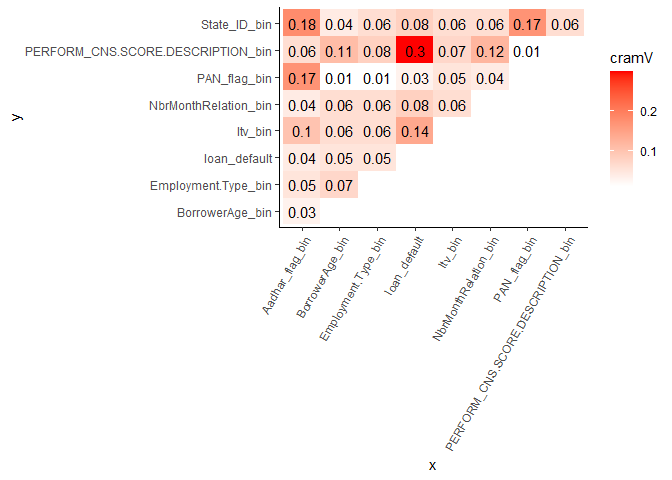

### 4.3.5 Dernières mises en forme

Nous n’avons pas plus d’information sur ces codes. Pour une question d’affichage, nous allons donc fixer leurs modalités à des valeurs génériques (group1, group2, etc.).

## 4.4 La regression logistique

Une fois nos données préparées et nos variables sélectionnées, nous pouvons ajuster une régression logistique (modèle classiquement utilisé).

Pour éviter le surapprentissage, il est toujours bien de séparer votre jeu de données en base d’apprentissage et base de test. Cette dernière base servira de référence pour l’analyse de performance.

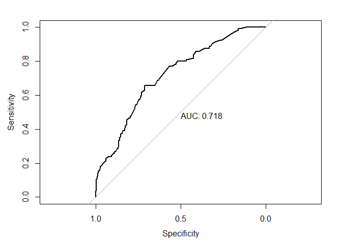

Graphiquement, on peut observer la distribution des scores selon le fait que le client soit tombé en défaut ou non :

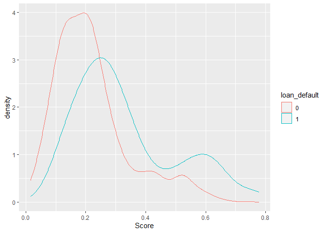

Comme attendu, les scores des clients tombant en défaut sont distribués dans les valeurs plus élevées. En effet, la régression logistique ajuste la probabilité d’avoir loan_default=1 en fonction des variables sélectionnées.